# pdac_psc

Richard Jackson

2025-03-22

## Example

The psc.r package is available for downlaod from CRAN and is obtianed using

```r
#install.packages("psc")
library(psc)
```

## PDAC

Pancreatic Cancer is one of the most deadly cancers with over 10,000 new cased per year and a poor prognosis. For 80% of patients the desease is either locally advanced or metastatic and whilst treatments are available, median survival is just 9 months.

For 20% of patietns, surgery to remove the cancer is an option. Whilst prognosis improves, median survival remains modest (approx 2 years) with roughly 30% of patietns living 5 years or more.

The European Study Group for Pancreatic Cacner (ESPAC) 4 study was a randomised controlled trial to compare 2 types of chemotherapy following survery in the 20% who are eligible. Seven hundred thirty two patients were randomised to two treatments; Gemcitabine (Gem: Control) and Gemcitbine plus Capecitabine (GemCap: Experimental). Ultimately this study was successful and demonstrate that GemCap can increase survival by approximately 3 months [HR= 0.82 (0.44, 0.98); P=value=0.039].

The ESPAC4 study followed on fromt he competion of ESPAC3, a smilar study in the same population. ESPAC3 also 1088 patients, 432 of which were randomised to receive Gemcitbine.

The aim here is to determine if the results of ESPAC4 can be replicated without the patients randomised to receive the control arm (Gem). Instead a model for Gemcitbine, developed on the ESPAC3 data, will be used.

## Gemcitabine Model (The counter-factual model)

```r
setwd("~/Documents/GitHub/pscLibrary/PDAC/GemVsGemCap")
load("flexParaGem.R")
```

This model constructed is a flexible parametric survvial model (‘fpm’) and has class ‘flexsurvreg’ and standard base functions can be used to explroe the model

```r
print(fpm)
```

```
## Call:
## flexsurvspline(formula = s.ob ~ t + grade + nodes + lca199, data = espac3,
##     k = 3)
##
## Estimates:
##         data mean  est       L95%      U95%      se        exp(est)  L95%
## gamma0        NA   -10.1835  -12.2917   -8.0753    1.0756        NA        NA
## gamma1        NA     2.8869    1.8733    3.9005    0.5172        NA        NA
## gamma2        NA     0.3284   -0.6240    1.2808    0.4859        NA        NA
## gamma3        NA    -0.5849   -2.1473    0.9774    0.7971        NA        NA
## gamma4        NA     0.5525   -0.2995    1.4045    0.4347        NA        NA
## t3        0.2173     0.5605    0.0382    1.0828    0.2665    1.7516    1.0390
## t4        0.7075     0.4198   -0.0615    0.9011    0.2456    1.5216    0.9403
## grade2    0.6212     0.4118    0.0673    0.7562    0.1757    1.5095    1.0697
## grade3    0.2312     0.7336    0.3461    1.1211    0.1977    2.0825    1.4135
## nodes2    0.7075     0.4862    0.2153    0.7570    0.1382    1.6261    1.2403
## lca199    3.4045     0.2057    0.1280    0.2834    0.0396    1.2284    1.1366
##         U95%
## gamma0        NA
## gamma1        NA
## gamma2        NA
## gamma3        NA
## gamma4        NA
## t3        2.9529
## t4        2.4624
## grade2    2.1301
## grade3    3.0682
## nodes2    2.1320
## lca199    1.3277
##
## N = 359,  Events: 309,  Censored: 50
## Total time at risk: 11533.31
## Log-likelihood = -1342.536, df = 11
## AIC = 2707.072
```

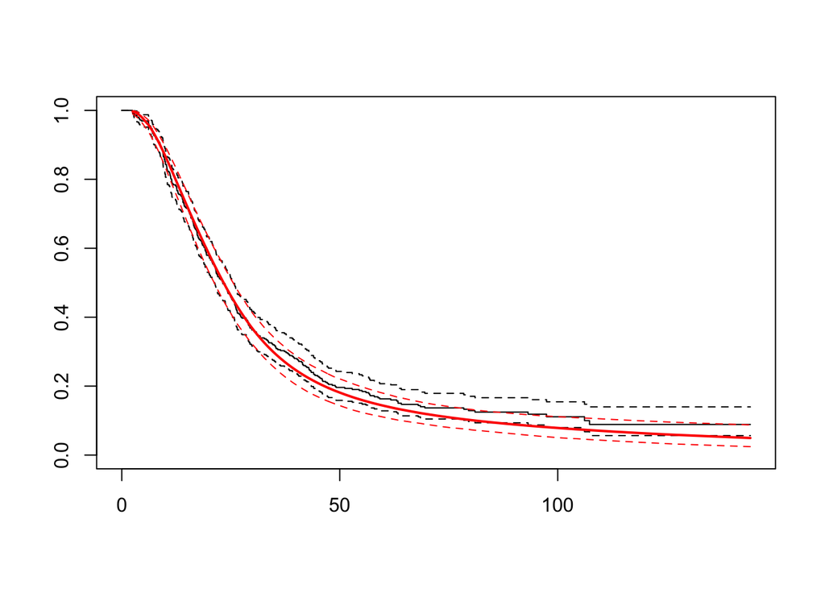

```r
plot(fpm)
```

## ESPAC 4 data

An anonymised subset of the data from the trial are used for this example and are available at (https://github.com/richJJackson/pscLibrary/tree/main/PDAC/GemVsGemCap). Data are available in .csv format:

```r
e4 <- read.csv("e4_data_cohort.csv")
head(e4)
```

```
##   X cen      time nodes grade   lca199 t
## 1 1   1 14.272704     1     2 3.526361 3
## 2 2   0 79.717317     1     2 2.484907 3
## 3 3   1 48.079669     1     2 1.791759 3
## 4 4   1  5.338895     1     2 3.663562 3
## 5 5   0 77.741299     1     3 1.774952 3
## 6 6   0 77.514692     1     1 2.944439 4
```

## Summary compariosns

The first step to comparing the espac 4 data to the Gem model is to ensure that the two sources of data are compatible. In practice the means esnuring that for each covariate in the model, there exists an equivalent covariate in the dataset. Care should be applied to ensure that these covaraites match, are vectors of the same class and are measured on the same scale.

The psc.r package includes a function dataComb.r which is contructued to create a single ‘cleaned’ object which includes both the model and the dataset. This includes a data_match.R fucntion which has the specific task of cheking the model and the data for compatibility. Both of these functions are included within the pscfit function for performing personalised synthetic contorls analyses and can also be run seperately.

The PSC methodology works on a complete case dataset and any observations with missing data will be removed. In this example 53 rows of data are removed and a warning message is provided to detail this.

```r
DC_clean <- dataComb(fpm,e4)
```

```
## Warning in dataComb.flexsurvreg(fpm, e4): 53 rows removed due to missing data
## in dataset
```

Beyond compatibility it is improtant to chekc that the model and the dataset are applied in the same setting. Whilst some of this comparsions will be qualitative, a useful check can be to check the distribution of the data cohort match this of the data in the model. The ‘cfmDataComp’ provides this as a grpahical summary and we use ggarrange to colate these into a single plot

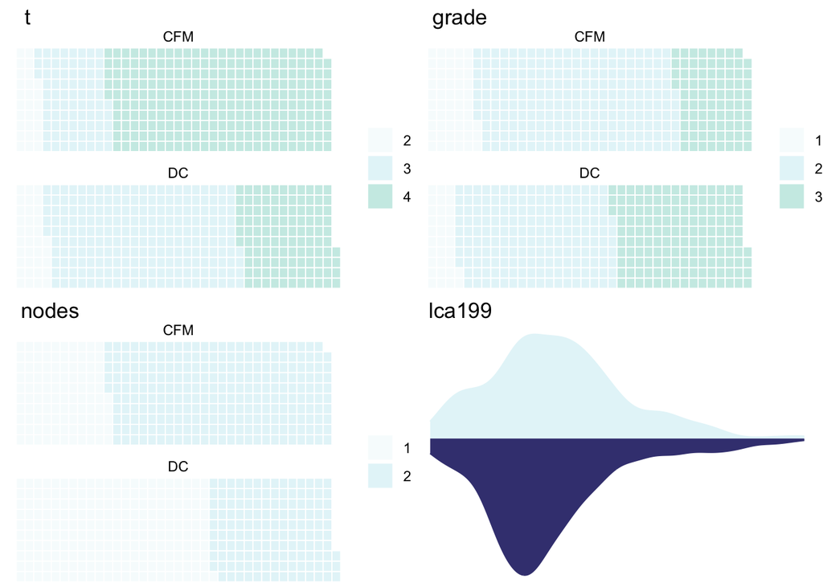

```r
visComp <- cfmDataComp(fpm,e4)
ggarrange(visComp[[1]],visComp[[2]],visComp[[3]],visComp[[4]])
```

## pscfit

The main function for perfoming Personalised Synthetic Controls is the pscfit function which requires as a minimum input the counterfactual model and the data cohrot.

NB this will perform the data cleaning routines

```r
pdac_psc <- pscfit(fpm,e4)
```

### pscfit options

```r
summary(pdac_psc)
```

```
## Summary:
##
## 311 observations selected from the data cohort for comparison
## CFM of type flexsurvreg identified
## linear predictor succesfully obtained with median:
##  trt: 1.786
## Average expected response:
##  trt: 30.077
## Average observed response: 26.327
##
## Counterfactual Model (CFM):
## A model of class 'flexsurvreg'
##  Fit with 3 internal knots
##
## Formula:
## s.ob ~ t + grade + nodes + lca199
## <environment: 0x1287ab238>
##
## Call:
##  CFM model + beta
##
## Coefficients:
##       median      2.5%        97.5%       Pr(x<0)     Pr(x>0)
## beta   -0.251304   -0.524838    0.005663    0.971400    0.028600
## DIC   845.648466  838.072019  861.571904          NA          NA
```

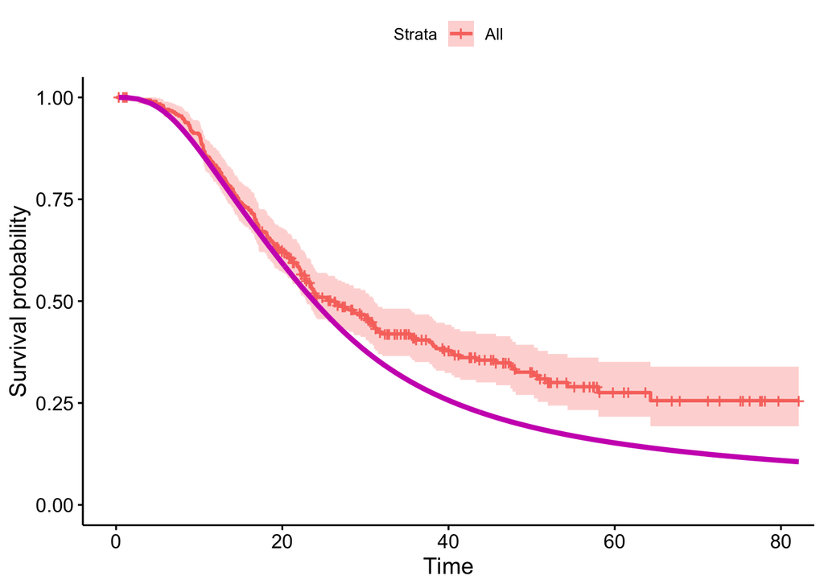

```r
plot(pdac_psc)
```